# Analyzing TMDB movie data from 1960 to 2015

- Introduction
- Data Wrangling
- Exploratory Data Analysis
- Conclusions

## Introduction

We will be analyzing a dataset from TMDB (The Movie Database). The dataset includes information about 10,000+ movies. The data included in teh dataset contains movie titles, budget, revenue, runtime, genres information, cast, director and much more. The dataset also includes budget and revenue dollars adjusted to 2010 dollars to account for inflation.

Through our analysis of the dataset we will aim to answer two questions:

```
1. What was the averge earnings of movies made year over year?
2. What was the most produced movie genre for the year I was born?
```

We start by importing the python libraries that we will use through the analysis of the TMDB Movie Data.

```python
import csv
from datetime import datetime
import numpy as np
import pandas as pd
import matplotlib.pyplot as plt
%matplotlib inline
```

```python
# set matplotlib figure size to something easier to look at
plt.rcParams['figure.dpi'] = 150
```

## Data Wrangling

The first step in data analysis is to have look at what the data looks like. To do this we will load up our csv dataset into a pandas dataframe (tmdb_data) and have a look at the first few rows.

```python
# create pandas dataframe from our csv dataset
tmdb_data = pd.read_csv('tmdb-movies.csv')

# view the first few rows of the dataframe
tmdb_data.head()
```

|  | id | imdb_id | popularity | budget | revenue | original_title | cast | homepage | director | tagline | ... | overview | runtime | genres | production_companies | release_date | vote_count | vote_average | release_year | budget_adj | revenue_adj |
| --- | --- | --- | --- | --- | --- | --- | --- | --- | --- | --- | --- | --- | --- | --- | --- | --- | --- | --- | --- | --- | --- |
| 0 | 135397 | tt0369610 | 32.985763 | 150000000 | 1513528810 | Jurassic World | Chris Pratt\|Bryce Dallas Howard\|Irrfan Khan\|Vi... | http://www.jurassicworld.com/ | Colin Trevorrow | The park is open. | ... | Twenty-two years after the events of Jurassic ... | 124 | Action\|Adventure\|Science Fiction\|Thriller | Universal Studios\|Amblin Entertainment\|Legenda... | 6/9/15 | 5562 | 6.5 | 2015 | 1.379999e+08 | 1.392446e+09 |
| 1 | 76341 | tt1392190 | 28.419936 | 150000000 | 378436354 | Mad Max: Fury Road | Tom Hardy\|Charlize Theron\|Hugh Keays-Byrne\|Nic... | http://www.madmaxmovie.com/ | George Miller | What a Lovely Day. | ... | An apocalyptic story set in the furthest reach... | 120 | Action\|Adventure\|Science Fiction\|Thriller | Village Roadshow Pictures\|Kennedy Miller Produ... | 5/13/15 | 6185 | 7.1 | 2015 | 1.379999e+08 | 3.481613e+08 |
| 2 | 262500 | tt2908446 | 13.112507 | 110000000 | 295238201 | Insurgent | Shailene Woodley\|Theo James\|Kate Winslet\|Ansel... | http://www.thedivergentseries.movie/#insurgent | Robert Schwentke | One Choice Can Destroy You | ... | Beatrice Prior must confront her inner demons ... | 119 | Adventure\|Science Fiction\|Thriller | Summit Entertainment\|Mandeville Films\|Red Wago... | 3/18/15 | 2480 | 6.3 | 2015 | 1.012000e+08 | 2.716190e+08 |
| 3 | 140607 | tt2488496 | 11.173104 | 200000000 | 2068178225 | Star Wars: The Force Awakens | Harrison Ford\|Mark Hamill\|Carrie Fisher\|Adam D... | http://www.starwars.com/films/star-wars-episod... | J.J. Abrams | Every generation has a story. | ... | Thirty years after defeating the Galactic Empi... | 136 | Action\|Adventure\|Science Fiction\|Fantasy | Lucasfilm\|Truenorth Productions\|Bad Robot | 12/15/15 | 5292 | 7.5 | 2015 | 1.839999e+08 | 1.902723e+09 |
| 4 | 168259 | tt2820852 | 9.335014 | 190000000 | 1506249360 | Furious 7 | Vin Diesel\|Paul Walker\|Jason Statham\|Michelle ... | http://www.furious7.com/ | James Wan | Vengeance Hits Home | ... | Deckard Shaw seeks revenge against Dominic Tor... | 137 | Action\|Crime\|Thriller | Universal Pictures\|Original Film\|Media Rights ... | 4/1/15 | 2947 | 7.3 | 2015 | 1.747999e+08 | 1.385749e+09 |

5 rows × 21 columns

As we can see from the output above our dateset contains 21 columns. Lets find out how many rows there are.

```python
# create a tuple representing the dimensionality of our data
rows, cols = tmdb_data.shape

# print the number of columns and rows (-1 to account for the header row)
print('There are {} columns and {} rows in the dataset.'.format(cols, rows-1, ))
```

[output not shown]

Now lets have a quick statistical look at our data.

```python
tmdb_data.describe()
```

|  | id | popularity | budget | revenue | runtime | vote_count | vote_average | release_year | budget_adj | revenue_adj |
| --- | --- | --- | --- | --- | --- | --- | --- | --- | --- | --- |
| count | 10866.000000 | 10866.000000 | 1.086600e+04 | 1.086600e+04 | 10866.000000 | 10866.000000 | 10866.000000 | 10866.000000 | 1.086600e+04 | 1.086600e+04 |
| mean | 66064.177434 | 0.646441 | 1.462570e+07 | 3.982332e+07 | 102.070863 | 217.389748 | 5.974922 | 2001.322658 | 1.755104e+07 | 5.136436e+07 |
| std | 92130.136561 | 1.000185 | 3.091321e+07 | 1.170035e+08 | 31.381405 | 575.619058 | 0.935142 | 12.812941 | 3.430616e+07 | 1.446325e+08 |
| min | 5.000000 | 0.000065 | 0.000000e+00 | 0.000000e+00 | 0.000000 | 10.000000 | 1.500000 | 1960.000000 | 0.000000e+00 | 0.000000e+00 |
| 25% | 10596.250000 | 0.207583 | 0.000000e+00 | 0.000000e+00 | 90.000000 | 17.000000 | 5.400000 | 1995.000000 | 0.000000e+00 | 0.000000e+00 |
| 50% | 20669.000000 | 0.383856 | 0.000000e+00 | 0.000000e+00 | 99.000000 | 38.000000 | 6.000000 | 2006.000000 | 0.000000e+00 | 0.000000e+00 |
| 75% | 75610.000000 | 0.713817 | 1.500000e+07 | 2.400000e+07 | 111.000000 | 145.750000 | 6.600000 | 2011.000000 | 2.085325e+07 | 3.369710e+07 |
| max | 417859.000000 | 32.985763 | 4.250000e+08 | 2.781506e+09 | 900.000000 | 9767.000000 | 9.200000 | 2015.000000 | 4.250000e+08 | 2.827124e+09 |

From the data above we can see that there are 0 values in budget, revenue, runtime, budjet_adj, and revenue_adj.

Since it is reasonable to assume that a movie that was procuded would have to cost something to make and would most likely at least have something to watch (greater than 0 minute runtime) lets remove that data from our dataset.

```python
# query the dataframe for rows where budget, runtime, or revenue are not equal to zero.
# replace the dataframe with the results
tmdb_data = tmdb_data.query('budget != 0')
tmdb_data = tmdb_data.query('runtime != 0')
tmdb_data = tmdb_data.query('revenue != 0')

# review the statiscal analysis after the changes
tmdb_data.describe()
```

|  | id | popularity | budget | revenue | runtime | vote_count | vote_average | release_year | budget_adj | revenue_adj |
| --- | --- | --- | --- | --- | --- | --- | --- | --- | --- | --- |
| count | 3855.000000 | 3855.000000 | 3.855000e+03 | 3.855000e+03 | 3855.000000 | 3855.000000 | 3855.00000 | 3855.000000 | 3.855000e+03 | 3.855000e+03 |
| mean | 39888.783398 | 1.191400 | 3.720183e+07 | 1.076589e+08 | 109.215824 | 527.611933 | 6.16786 | 2001.263294 | 4.423630e+07 | 1.370294e+08 |
| std | 67213.815955 | 1.475002 | 4.220291e+07 | 1.765248e+08 | 19.922166 | 879.868374 | 0.79504 | 11.281989 | 4.480403e+07 | 2.160944e+08 |
| min | 5.000000 | 0.001117 | 1.000000e+00 | 2.000000e+00 | 15.000000 | 10.000000 | 2.20000 | 1960.000000 | 9.693980e-01 | 2.370705e+00 |
| 25% | 6074.000000 | 0.462448 | 1.000000e+07 | 1.357645e+07 | 95.000000 | 71.000000 | 5.70000 | 1995.000000 | 1.309053e+07 | 1.834123e+07 |
| 50% | 11322.000000 | 0.797298 | 2.400000e+07 | 4.479322e+07 | 106.000000 | 204.000000 | 6.20000 | 2004.000000 | 3.001558e+07 | 6.171861e+07 |
| 75% | 38577.000000 | 1.368245 | 5.000000e+07 | 1.241530e+08 | 119.000000 | 580.000000 | 6.70000 | 2010.000000 | 6.061307e+07 | 1.632401e+08 |
| max | 417859.000000 | 32.985763 | 4.250000e+08 | 2.781506e+09 | 338.000000 | 9767.000000 | 8.40000 | 2015.000000 | 4.250000e+08 | 2.827124e+09 |

Based on the min value of each column, we now see that row with 0 have been removed from our dataset.

Lets have a look at how many rows remain.

```python
#create a tuple representing the dimensionality of our data
rows, cols = tmdb_data.shape

# print the number of columns and rows (-1 to account for the header row)
print('There are {} columns and {} rows in the dataset.'.format(cols, rows-1, ))
```

[output not shown]

### Data Cleaning

Lets start by cleaning up the data so it will be more useful once we get to the analysis phase.

For the purpose of the analysis that we are going to perform there are a number of columns that are not needed. So lets go ahead and remove those now.

We will be removing the id, imdb_id, popularity, homepage, tagline, keywords, overview, and vote_count columns.

```python
# creating a list of columns to remove
cols_to_remove = ['id', 'imdb_id', 'popularity', 'homepage', 'tagline', 'keywords', 'overview', 'vote_count']

# removing the columns and saving the remaining columns to our tmdb_data dataframe
tmdb_data = tmdb_data.drop(cols_to_remove, 1)

# view the first few rows of the dataframe again
tmdb_data.head()
```

|  | budget | revenue | original_title | cast | director | runtime | genres | production_companies | release_date | vote_average | release_year | budget_adj | revenue_adj |
| --- | --- | --- | --- | --- | --- | --- | --- | --- | --- | --- | --- | --- | --- |
| 0 | 150000000 | 1513528810 | Jurassic World | Chris Pratt\|Bryce Dallas Howard\|Irrfan Khan\|Vi... | Colin Trevorrow | 124 | Action\|Adventure\|Science Fiction\|Thriller | Universal Studios\|Amblin Entertainment\|Legenda... | 6/9/15 | 6.5 | 2015 | 1.379999e+08 | 1.392446e+09 |
| 1 | 150000000 | 378436354 | Mad Max: Fury Road | Tom Hardy\|Charlize Theron\|Hugh Keays-Byrne\|Nic... | George Miller | 120 | Action\|Adventure\|Science Fiction\|Thriller | Village Roadshow Pictures\|Kennedy Miller Produ... | 5/13/15 | 7.1 | 2015 | 1.379999e+08 | 3.481613e+08 |
| 2 | 110000000 | 295238201 | Insurgent | Shailene Woodley\|Theo James\|Kate Winslet\|Ansel... | Robert Schwentke | 119 | Adventure\|Science Fiction\|Thriller | Summit Entertainment\|Mandeville Films\|Red Wago... | 3/18/15 | 6.3 | 2015 | 1.012000e+08 | 2.716190e+08 |
| 3 | 200000000 | 2068178225 | Star Wars: The Force Awakens | Harrison Ford\|Mark Hamill\|Carrie Fisher\|Adam D... | J.J. Abrams | 136 | Action\|Adventure\|Science Fiction\|Fantasy | Lucasfilm\|Truenorth Productions\|Bad Robot | 12/15/15 | 7.5 | 2015 | 1.839999e+08 | 1.902723e+09 |
| 4 | 190000000 | 1506249360 | Furious 7 | Vin Diesel\|Paul Walker\|Jason Statham\|Michelle ... | James Wan | 137 | Action\|Crime\|Thriller | Universal Pictures\|Original Film\|Media Rights ... | 4/1/15 | 7.3 | 2015 | 1.747999e+08 | 1.385749e+09 |

Next lets have a look the date format release_date column. It certainly looks like a date, but may be difficult to work with like that. We will go ahead and change the date into a format that is easier to work with. Lets change it a yyyy-mm-dd format.

```python
# convert release_date column to a datetime format
tmdb_data.release_date = pd.to_datetime(tmdb_data['release_date'])

# create a temporary dataframe to view the changes made to the column
output = tmdb_data[['release_date']]
output.head()
```

|  | release_date |
| --- | --- |
| 0 | 2015-06-09 |
| 1 | 2015-05-13 |
| 2 | 2015-03-18 |
| 3 | 2015-12-15 |
| 4 | 2015-04-01 |

To me looking at a number like 1.839999e+08 hurts my brain. Since we are dealing with large numbers here lets go ahead and convert these to dollars in millions.

```python
# create a function to convert dollar values to millions
def convert_to_millions(dataframe, col):
    dataframe[col + "_in_millions"] = dataframe.apply(lambda row: row[col] / 1000000, axis =1)
    dataframe = dataframe.drop(col, axis=1, inplace=True)
    return tmdb_data

# convert columns (budget, revenue, budget_adj, and revenue_adj) to dollars in millions
convert_to_millions(tmdb_data, 'budget')
convert_to_millions(tmdb_data, 'revenue')
convert_to_millions(tmdb_data, 'budget_adj')
convert_to_millions(tmdb_data, 'revenue_adj')

# create a temporary dataframe to view the changes made to the columns
output = tmdb_data[['budget_in_millions','revenue_in_millions','budget_adj_in_millions','revenue_adj_in_millions']]
output.head()
```

|  | budget_in_millions | revenue_in_millions | budget_adj_in_millions | revenue_adj_in_millions |
| --- | --- | --- | --- | --- |
| 0 | 150.0 | 1513.528810 | 137.999939 | 1392.445893 |
| 1 | 150.0 | 378.436354 | 137.999939 | 348.161292 |
| 2 | 110.0 | 295.238201 | 101.199955 | 271.619025 |
| 3 | 200.0 | 2068.178225 | 183.999919 | 1902.723130 |
| 4 | 190.0 | 1506.249360 | 174.799923 | 1385.748801 |

The represented dollar columns are looking better, but we can probably do a little more. Since we are working with large numbers lets go ahead and get rid of the zeros after the decimal by converting the data types from float to int.

```python
# create a list to hold the columns we want to convert
float_to_int = ['budget_in_millions', 'revenue_in_millions', 'budget_adj_in_millions', 'revenue_adj_in_millions']

# convert those columns to int64 data type
tmdb_data[float_to_int] = tmdb_data[float_to_int].applymap(np.int64)

# create a temporary dataframe to view the changes made to the columns
output = tmdb_data[['budget_in_millions','revenue_in_millions','budget_adj_in_millions','revenue_adj_in_millions']]
output.head()
```

|  | budget_in_millions | revenue_in_millions | budget_adj_in_millions | revenue_adj_in_millions |
| --- | --- | --- | --- | --- |
| 0 | 150 | 1513 | 137 | 1392 |
| 1 | 150 | 378 | 137 | 348 |
| 2 | 110 | 295 | 101 | 271 |
| 3 | 200 | 2068 | 183 | 1902 |
| 4 | 190 | 1506 | 174 | 1385 |

We also know that we want see data related to the earnings (revenue - budget) so lets go ahead and add that column now.

```python
# subtract budget_adj from revenue_adj and save in earnings column
tmdb_data['earnings_adj_in_millions'] = tmdb_data.apply(lambda row: row['revenue_adj_in_millions'] - row['budget_adj_in_millions'], axis =1)

# create a temporary dataframe to view the new column created
output = tmdb_data[['revenue_adj_in_millions','budget_adj_in_millions','earnings_adj_in_millions']]
output.head()
```

|  | revenue_adj_in_millions | budget_adj_in_millions | earnings_adj_in_millions |
| --- | --- | --- | --- |
| 0 | 1392 | 137 | 1255 |
| 1 | 348 | 137 | 211 |
| 2 | 271 | 101 | 170 |
| 3 | 1902 | 183 | 1719 |
| 4 | 1385 | 174 | 1211 |

## Exploratory Data Analysis

```
Now that we have our data the way we want it, it's time for the fun part!
```

### Research Question 1: What is the averge earnings of movies made year over year?

```
Lets start by looking at the averge budget of all the movies in our dataset.
```

```python
# find the average of the budget_in_millions column and return it as an int
avg_budget = int(tmdb_data['budget_in_millions'].mean())

# find the minimum year from the release_year column
min_release_year = tmdb_data['release_year'].min()

# find the maximum year from the release_year column
max_release_year = tmdb_data['release_year'].max()

print('The average budget to make a movie between {} and {} was ${} million dollars.'.format(min_release_year, max_release_year, avg_budget))
```

```
The average budget to make a movie between 1960 and 2015 was $37 million dollars.
```

Lets also look at the average budget of a movie by year when accounting for inflation.

```python
# find the average of the budget_adj_in_millions column and return it as an int
avg_budget_adj = int(tmdb_data['budget_adj_in_millions'].mean())

print('The average budget to make a movie between {} and {} was ${} million dollars adjust for 2010 dollars.'.format(min_release_year, max_release_year, avg_budget_adj))
```

```
The average budget to make a movie between 1960 and 2015 was $43 million dollars adjust for 2010 dollars.
```

Now that we know how much the average budget was for movies made between 1960 and 2015 in our dataset, lets look at the data at a more granular level.

First we will look at the average budget by year.

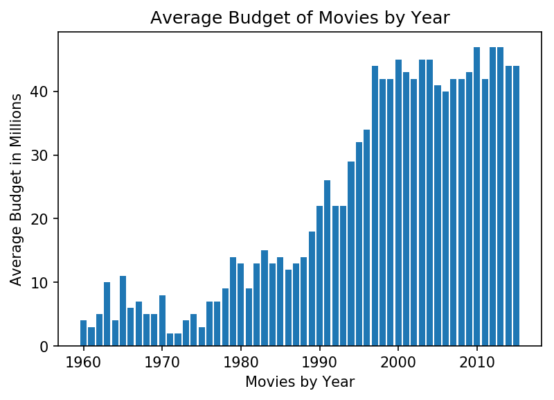

```python
budget_by_year = tmdb_data.groupby('release_year', as_index=False)['budget_in_millions'].mean().astype(np.int32)

plt.xlabel('Movies by Year')
plt.ylabel('Average Budget in Millions')
plt.title('Average Budget of Movies by Year')

plt.bar(budget_by_year['release_year'],budget_by_year['budget_in_millions'])
plt.show()
```

As expected it looks like the budget for a movie has risen over time. However, as noted before, this doesn't account for inflation. After all a dollar in 1960 wasn't worth the same as a dollar in 2015.

Lets have a look at this same data (average budget by year), but adjusted for inflation (represtnted in 2010 dollars)

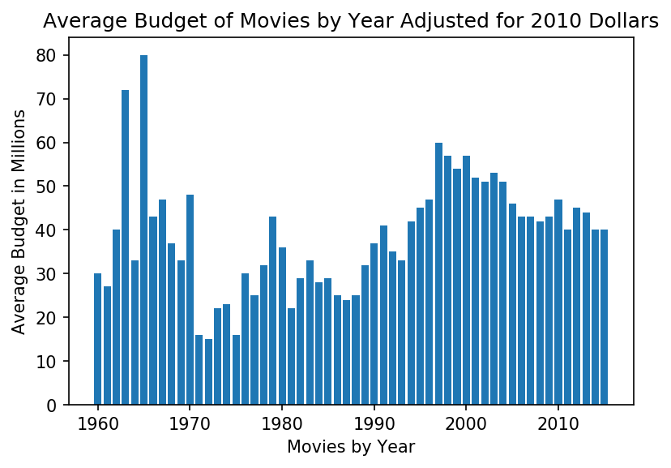

```python
budget_by_year_adj = tmdb_data.groupby('release_year', as_index=False)['budget_adj_in_millions'].mean().astype(np.int32)

plt.xlabel('Movies by Year')
plt.ylabel('Average Budget in Millions')
plt.title('Average Budget of Movies by Year Adjusted for 2010 Dollars')

plt.bar(budget_by_year_adj['release_year'],budget_by_year_adj['budget_adj_in_millions'])
plt.show()
```

Now that data looks a bit different. It seems that the average budget adjusted is moslty consistent with, lower budgets in the 1970's and what appear to be a couple very expensive movie making years in the 1960's.

Now that we've looked at the average budget for movies, lets have a look at the average revenue.

**NOTE: all subsequent analysis wil be perfomed on the 2010 adjusted dollar.**

```python
# find the average of the revenue_adj_in_millions column and return it as an int
avg_revenue_adj = int(tmdb_data['revenue_adj_in_millions'].mean())

print('The average revenue from a movie between {} and {} was ${} million dollars adjust for 2010 dollars.'.format(min_release_year, max_release_year, avg_revenue_adj))
```

```
The average revenue from a movie between 1960 and 2015 was $136 million dollars adjust for 2010 dollars.
```

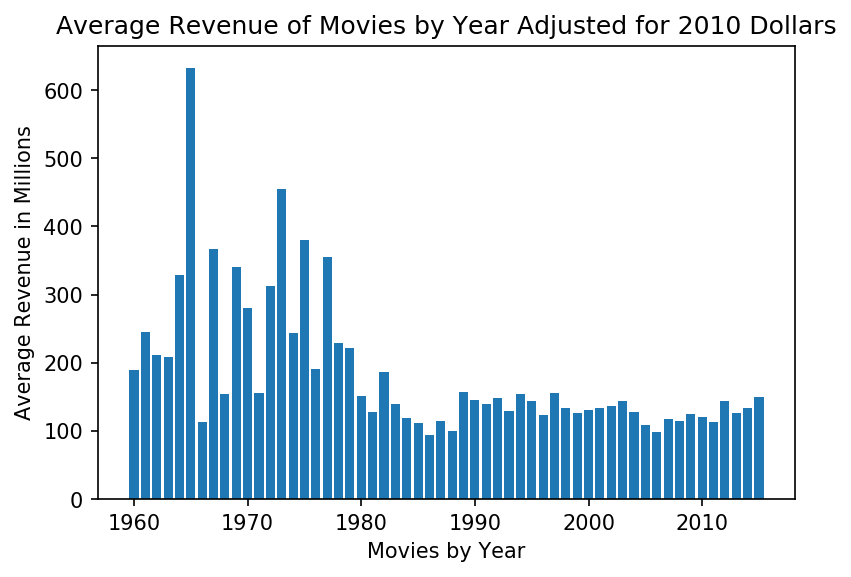

```python
revenue_by_year_adj = tmdb_data.groupby('release_year', as_index=False)['revenue_adj_in_millions'].mean().astype(np.int64)

plt.xlabel('Movies by Year')
plt.ylabel('Average Revenue in Millions')
plt.title('Average Revenue of Movies by Year Adjusted for 2010 Dollars')

plt.bar(revenue_by_year_adj['release_year'],revenue_by_year_adj['revenue_adj_in_millions'])
plt.show()
```

Again we see that when adjusted for inflation average revenue year over year seems to remain consitant. Though it looks like the movie industry had a boom in the mid 1960 through mid 1970.

Now that we've looked at Average Budget and Average Revenue independant of each other, lets see how they look when compared side by side.

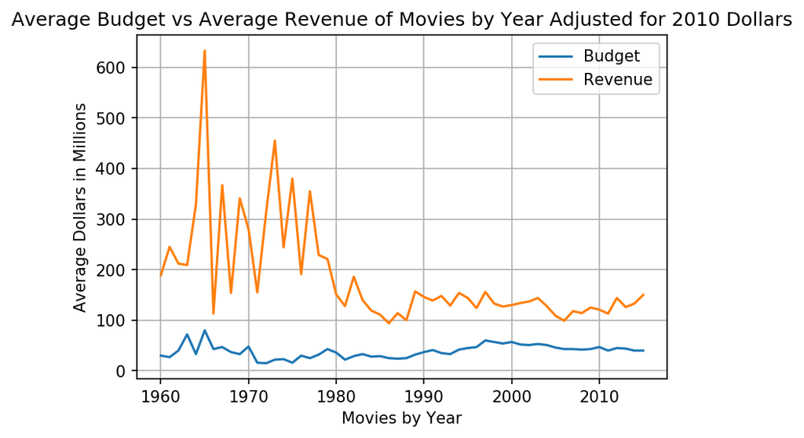

```python
plt.plot(budget_by_year_adj['release_year'],budget_by_year_adj['budget_adj_in_millions'], label = 'Budget')
plt.plot(revenue_by_year_adj['release_year'],revenue_by_year_adj['revenue_adj_in_millions'], label = 'Revenue')

plt.xlabel('Movies by Year')
plt.ylabel('Average Dollars in Millions')
plt.title('Average Budget vs Average Revenue of Movies by Year Adjusted for 2010 Dollars')
plt.grid()
plt.legend(loc = 'upper right')
```

It would appear that the movie industry isn't exactly hurting. Though profit margins may be getting slimmer than the hay days of the 1970's there still seems to be profit in it.

So, what is the earnings per year? Though we could derive that information from the above line chart, it would be much easier to look at side by side in a bar chart.

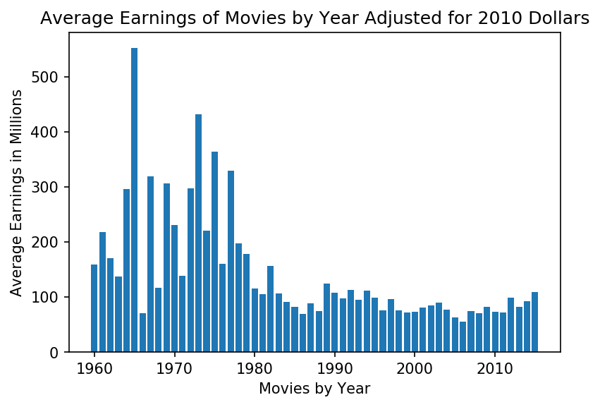

```python
earnings_by_year_adj = tmdb_data.groupby('release_year', as_index=False)['earnings_adj_in_millions'].mean().astype(np.int64)

plt.xlabel('Movies by Year')
plt.ylabel('Average Earnings in Millions')
plt.title('Average Earnings of Movies by Year Adjusted for 2010 Dollars')

plt.bar(earnings_by_year_adj['release_year'],earnings_by_year_adj['earnings_adj_in_millions'])
plt.show()
```

### Research Question 2 : What was the most produced movie genre for the year I was born?

The next question we aim to answer with our dataset is whatwas the most popular genre from each year?

To analyze this data we are going to create a new dataframe that contains only the years and genres that are in our dataset.

We will start by determining the range of years to include in our new dataframe.

```python
# determine the range of valid years in our dataset to use as the index
years_in_dataset = range(tmdb_data['release_year'].min(), tmdb_data['release_year'].max() + 1)


print(years_in_dataset)
```

```
range(1960, 2016)
```

We add a 1 to the max year so that the last year (2015) will be included in our dataframe. The last number in the range is not included.

Next we will create a set of valid genres included in our dataset.

```python
# create a set of valid genres from our dataset to serve as column headers
# a set is used here to ensure we do not get dupliucate values
genre_list = list(tmdb_data['genres'])
genre_set = set()
for item in genre_list:
        cell = item.split('|')
        for value in cell:
            genre_set.add(value)

print(genre_set)
```

```
{'Drama', 'Music', 'Documentary', 'Adventure', 'Thriller', 'Comedy', 'Animation', 'Fantasy', 'Family', 'Western', 'Romance', 'War', 'Action', 'Crime', 'Foreign', 'Mystery', 'Science Fiction', 'Horror', 'TV Movie', 'History'}
```

Now we will create our new dataframe utilizing the years as the index and the genres as the columns.

```python
# create new dataframe using years as the index and genres as column headers
years_genres_dataframe = pd.DataFrame(index = years_in_dataset, columns = genre_set)

# dataframe is created with NAN value in cells
# replace all NAN values with zeroes so we can increment the counts later
years_genres_dataframe = years_genres_dataframe.fillna(0)

# veiw first few rows of the new dataframe
years_genres_dataframe.head()
```

|  | Drama | Music | Documentary | Adventure | Thriller | Comedy | Animation | Fantasy | Family | Western | Romance | War | Action | Crime | Foreign | Mystery | Science Fiction | Horror | TV Movie | History |
| --- | --- | --- | --- | --- | --- | --- | --- | --- | --- | --- | --- | --- | --- | --- | --- | --- | --- | --- | --- | --- |
| 1960 | 0 | 0 | 0 | 0 | 0 | 0 | 0 | 0 | 0 | 0 | 0 | 0 | 0 | 0 | 0 | 0 | 0 | 0 | 0 | 0 |
| 1961 | 0 | 0 | 0 | 0 | 0 | 0 | 0 | 0 | 0 | 0 | 0 | 0 | 0 | 0 | 0 | 0 | 0 | 0 | 0 | 0 |
| 1962 | 0 | 0 | 0 | 0 | 0 | 0 | 0 | 0 | 0 | 0 | 0 | 0 | 0 | 0 | 0 | 0 | 0 | 0 | 0 | 0 |
| 1963 | 0 | 0 | 0 | 0 | 0 | 0 | 0 | 0 | 0 | 0 | 0 | 0 | 0 | 0 | 0 | 0 | 0 | 0 | 0 | 0 |
| 1964 | 0 | 0 | 0 | 0 | 0 | 0 | 0 | 0 | 0 | 0 | 0 | 0 | 0 | 0 | 0 | 0 | 0 | 0 | 0 | 0 |

As you can see above, the dataframe is created. The new dataframe was created with NAN values, however since we will want to populate the information by adding the number of times the genre appears for each year, we replaced all the NAN values with 0.

The last thing to do here is to populate the dataframe with the number of times a genre appears for each year from our dataset.

```python
# populate the new dataframe by iterating over the dataset and incrementing the year and genre cells
for row in tmdb_data.itertuples():
    genres_by_row = row.genres.split('|')
    year = row.release_year
    for genre in genres_by_row:
        years_genres_dataframe.loc[year, genre] = years_genres_dataframe.loc[year, genre] + 1

# veiw first few rows of the populated dataframe
years_genres_dataframe.head()
```

|  | Drama | Music | Documentary | Adventure | Thriller | Comedy | Animation | Fantasy | Family | Western | Romance | War | Action | Crime | Foreign | Mystery | Science Fiction | Horror | TV Movie | History |
| --- | --- | --- | --- | --- | --- | --- | --- | --- | --- | --- | --- | --- | --- | --- | --- | --- | --- | --- | --- | --- |
| 1960 | 3 | 0 | 0 | 1 | 1 | 2 | 0 | 0 | 0 | 1 | 2 | 0 | 2 | 0 | 0 | 0 | 0 | 1 | 0 | 1 |
| 1961 | 6 | 1 | 0 | 2 | 0 | 4 | 1 | 0 | 2 | 1 | 1 | 1 | 2 | 1 | 0 | 0 | 0 | 1 | 0 | 1 |
| 1962 | 5 | 0 | 0 | 3 | 1 | 0 | 0 | 0 | 0 | 2 | 0 | 1 | 2 | 1 | 0 | 0 | 0 | 0 | 0 | 1 |
| 1963 | 3 | 0 | 0 | 2 | 3 | 1 | 0 | 0 | 0 | 0 | 2 | 1 | 2 | 0 | 0 | 1 | 0 | 1 | 0 | 3 |
| 1964 | 4 | 3 | 0 | 1 | 2 | 3 | 0 | 1 | 2 | 0 | 2 | 1 | 1 | 1 | 0 | 1 | 0 | 0 | 0 | 0 |

Now we can start creating some visual represtations of our data.

First we'll create a series that contains all our genres and thier total counts.

```python
all_genres_totals = pd.Series(np.zeros(len(genre_set)), index = genre_set)
for genre in genre_set:
    all_genres_totals.loc[genre] = years_genres_dataframe[genre].sum()

print(all_genres_totals)
```

```
Drama              1757.0
Music               136.0
Documentary          35.0
Adventure           749.0
Thriller           1205.0
Comedy             1358.0
Animation           201.0
Fantasy             396.0
Family              425.0
Western              52.0
Romance             667.0
War                 119.0
Action             1086.0
Crime               652.0
Foreign              13.0
Mystery             344.0
Science Fiction     520.0
Horror              463.0
TV Movie              1.0
History             129.0
dtype: float64
```

Next we will use this data to view the percentage each genre shows up in a pie chart.

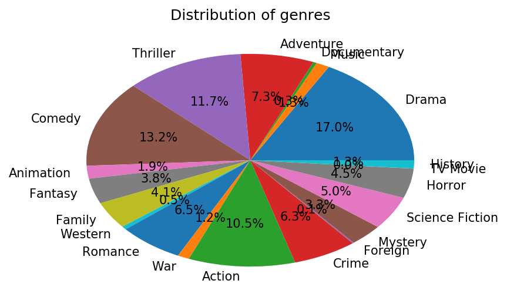

```python
# create a variable to get the keys from all_genres_totals to use as the labels for our pie chart
genre_distribution = list(all_genres_totals.keys())

# plot percentage of each genre in a pie chart
plt.pie(all_genres_totals, labels = genre_distribution, autopct = '%.1f%%')
plt.title("Distribution of genres")
plt.show()
```

Now we have a pie chart that displays all the genres and thier distribtions, however it is not pretty and not easy to read.

We can certainly do better. Lets make some changes so we only see the top 10 genres and lump the rest into an "Others" category. While we're at it, lets sort the value in descending order so it's easier to read.

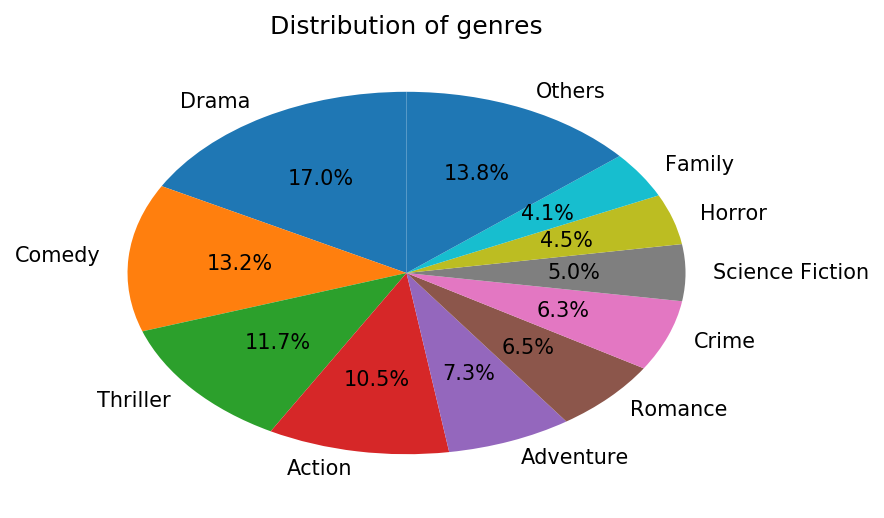

```python
# create a variable to hold the number of genres we want to see
n=10

# create variable to hold top 10 genre totals
genres_top_ten = all_genres_totals.sort_values(ascending = False)[0:n]

# get the top 10 key values to be used as labels
genre_distribution = list(all_genres_totals.sort_values(ascending = False).keys())[0:n]

# create an 'Others' label to capture the rest
genre_distribution.append('Others')

# sum up the remaining (not the top 10) genres values
other_genres = all_genres_totals.sort_values(ascending = False)[n:].sum()

# assign the value of total of 'Others'
genres_top_ten.at['Others'] = other_genres

# plot percentage of each genre in a pie chart
plt.pie(genres_top_ten, labels = genre_distribution, autopct = '%.1f%%', startangle = 90)
plt.title("Distribution of genres")
plt.show()
```

Now this is much better! We can clearly see the top ten genres and percentage of the total genres they represent.

From this chart it is easy to tell that Drama was the most produced genre from 1960 to now. Now that we know the overall percentage of each genre produced between 1960 and 2015, lets have a look at 1978 (the year I was born).

Lets create a series to hold just the genre totals from th year 1978.

```python
# create variable to hold desired year
year_born = 1978

# create a dataframe to hold just the wanted years values
year_born_genre_dataframe = years_genres_dataframe.query('index == @year_born')

# create a series for each genre and it's value
year_born_genre_totals = pd.Series(np.zeros(len(genre_set)), index = genre_set)
for genre in genre_set:
    year_born_genre_totals.loc[genre] = year_born_genre_dataframe[genre].sum()

#tmdb_data = tmdb_data.query('budget != 0')
print(year_born_genre_totals)
```

```
Drama              7.0
Music              2.0
Documentary        0.0
Adventure          5.0
Thriller           5.0
Comedy             2.0
Animation          2.0
Fantasy            2.0
Family             1.0
Western            0.0
Romance            0.0
War                2.0
Action             5.0
Crime              1.0
Foreign            0.0
Mystery            2.0
Science Fiction    3.0
Horror             5.0
TV Movie           0.0
History            0.0
dtype: float64
```

Now we can create a pie chart to represent just one years information.

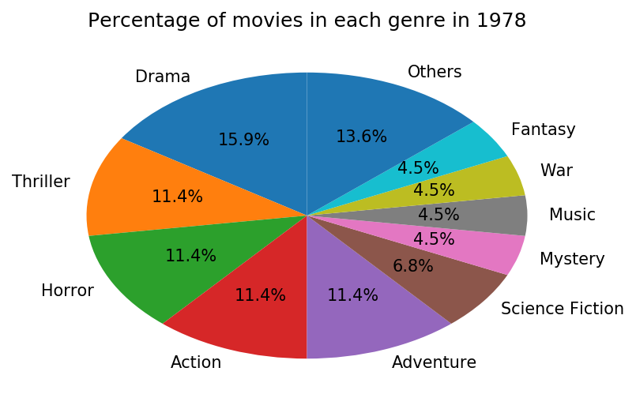

```python
# create a variable to hold the number of genres we want to see
n=10

# create variable to hold top 10 genre totals
genres_top_ten = year_born_genre_totals.sort_values(ascending = False)[0:n]

# get the top 10 key values to be used as labels
genre_distribution = list(years_genres_dataframe.loc[year_born].sort_values(ascending = False).keys())[0:n]

# create an 'Others' label to capture the rest
genre_distribution.append('Others')

# sum up the remaining (not the top 10) genres values
other_genres = year_born_genre_totals.sort_values(ascending = False)[n:].sum()

# assign the value of total of 'Others'
genres_top_ten.at['Others'] = other_genres

# plot percentage of each genre in a pie chart
plt.pie(genres_top_ten, labels = genre_distribution, autopct = '%.1f%%', startangle = 90)
plt.title("Percentage of movies in each genre in {}".format(year_born))
plt.show()
```

## Conclusions

Based on the analysis of the dataset we see that some years have been very profitable, while other have not and although profitiablity does appear to have declined over the years movies are still making money.

We were also able to determine that Drama seems to be the most produced genre in the movie industry.

#### Limitations

- For the purpose of this analysis we only looked at dollar represented values (Budget, Revenue, and the derived Earnings) as well as the information held in the Genre column
- The dataset contained many zero values for information we would expect to see actual values
  - When all zero values were removed we were left with only approximately 35% of the dataset, possibly removing valid information
- Dollar values analysed were adjusted for 2010 values to account for inflation in order to make more accurate comparisons
  - This has the effect of dollar values possibly not being accurately represented
- The Genres column may have contained mutlipe values for each movie
  - All genre values were captured in the analysis therefore movies were counted multiple times when determing percentages of genres produced